# Mineração de dados: decisões judiciais

Pedro

2022-07-17

# Pacotes utilizados

```r
library(wordcloud)
library(wordcloud2)
library(BiocManager, Rgraphiz)
library(tm, NLP)
knitr::opts_chunk$set(warning = FALSE, message = FALSE)
```

TM (*text mining*) e NLP(*Natural Language process*) são as duas principais técnicas de análise de mineração de textos.

*World cloud1* e *World Cloud* proporcionam a nuvem de palavras mais frequentes nos textos.

## Carregando as decisões

```r
txt <- system.file("texts", "txt", package = "tm") #carregando os as decisões em formato txt

ovid <- VCorpus(DirSource(txt, encoding = "UTF-8"),
                 readerControl = list(language = "por"))
#preparando os textos para serem lidos e processados pelo R
```

## Tokenização e remoção de termos indesejados

```r
ovid = tm_map(ovid, removeWords,stopwords('portuguese'))
#stopwords portuguese é um banco criado por colaboradores para extrair palavras indesejadas na análise

ovid = tm_map(ovid, stripWhitespace)
#reduz os espaços em branco

ovid = tm_map(ovid, removePunctuation)
#extrai pontuação

ovid = tm_map(ovid, removeNumbers)
#extrai números

ovid = tm_map(ovid, content_transformer(tolower))
#passa todas as palavras para caixa baixa para criar um padrão
```

O pacote TM têm diversas funções para extrair caracteres que são indesejados na análise de textos como artigos e preposições. Mesmo com a aplicação de todos estes métodos, diversas palavras repetidas, típicas aos textos jurídicos, permaneceram. Além disso, nomes próprios permaneceram, números de artigos, datas e etc.

Por essa razão foi necessário acrescentar diversas outras palavaras que, ainda, deveriam ser desconsideradas.

O comando **removeWords** permite essa extração manualmente.

```r
ovid <- tm_map(ovid, removeWords, c("ricardo", "nesse", "neste",
                                    "viii", "xii", "xiii",  "xiv",
                                    "col","reynaldo",
                                    "soares", "abrigadas" , "abstratas",
                                    "configurar",  "confira", "confirmação" ,
                                    "conheço", "art", "ronaldo", "tjpe",
                                    "rogerio", "pimentel", "pgc",
                                    "anos", "ser", "lei",
                                    "ordem", "tribunal", "corpus",
                                    "habeas", "caso", "pena", "ainda",
                                    "aplicação", "substituição", "sendo",
                                    "fls", "paulo", "forma", "situação",
                                    "superior", "conforme", "custodiada",
                                    "além", "deve", "dje", "bem", "tal",
                                    "caput", "iii", "onde", "sobre",
                                    "causa", "local", "necessidade",
                                    "turma", "razão", "assim", "sob",
                                    "ter", "código", "cpp", "thais",
                                    "fato", "dois", "tendo", "sentido", "dentro",
                                    "grifei", "termos", "quais", "ambos",
                                    "nesta", "página", "relator", "relatório", "ericles",
                                    "bangkok", "catarina",  "catarinense",
                                    "boa", "schietti", "admitir", "seguindo",
                                    "conferido", "conferir", "conter", "constando",
                                    "cultura", "deletérios", "félix", "marina",
                                    "marcelo", " àqueles", "arruda", "brasileiro",
                                    "brasília", "aptos", "configurar", "configurada",
                                    "considerada", "contato", "corroboram", "daí",
                                    "demonstradas", "demonstre", "dispõem", "exigir",
                                    "exigiria", "leopoldo", "lucas",
                                    "rio", "preventiva", "autos",
                                    "ofício", "paciente", "concessão",
                                    "defesa", "janeiro", "concreto",
                                    "acometido", "alyne", "alguém",
                                    "aludido", "analisada", "apenada", "apenados",
                                    "analógica", "antecipada", "apoiar", "apadrinhada",
                                    "aplicável", "arbitrariedade", "assiduamente",
                                    "assiste", "atente", "avaliada", "avisos",
                                    "basilares", "beneficente", "cabal", "cadernos",
                                    "calibre", "canaro", "célere", "celeridade",
                                    "cargo", "colheu", "comandada", "comitê",
                                    "compatível", "competência", "compreensão",
                                    "concretização", "condenadas", "certidões",
                                    "ciente", "admitirá",
                                    "assiduament", "aluno", "alyn",
                                    "damião", "deferida", "deferir",
                                    "atent", "arbitrariedad", "amplitud",
                                    "amplo", "apenado", "apontada","arbitrariedad",
                                    "armada","assiduament", "assist", "atent", "atuando",
                                    "ausentar", "autorizadora", "auxiliada", "avaliado",
                                    "aviso", "basilar",  "batizada",
                                    "beneficent", "beneficiário", "burocratizada",
                                    "certidõ",  "cient", "clarament", "coator", "colaciono",
                                    "conferida" , "contrariedad",
                                    "contraturno",    "controvérsia" , "convivência",
                                    "damião", "debilitado", "deferida", "deferir",
                                    "delimitar", "denotada",  "depen",  "desconstituir",
                                    "descrito", "convocado",  "correspondência", "crescent",
                                    "cumprida", "cumprido", "despacho", "desproveu",  "desvalor",
                                    "detençõ","diapasão", "diferent", "direcionam", "discriminação",
                                    "doença", "dominant",   "educação",   "eficácia", "eleita", "elenca",
                                    "elencarem", "eliminação", "embasada" , "ementado", "emitido",  "empecilho",
                                    "adpf", "coisas"))
```

## Preparando a nuvem de palavras

```r
tdm <-  TermDocumentMatrix(ovid)
#armazenando palavras com maior frequência

m = as.matrix(tdm) #transformando em matriz
v = sort(rowSums(m), decreasing = TRUE) #ordenando pela frequência
d = data.frame(word = names(v), freq = v) #transformando em dataframe

library(RColorBrewer) #pacote complementar para cores no wordcloud

wordcloud2(d)
```

[interactive chart not shown]

A nuvem de palavras indica que a principal pena aplicada entre as decisões analisadas é a prisão e a prisão domiciliar. Mais do que isso, a maioria esmagadora dos crimes julgados envolvem tráfico de drogas.

## Análise sobre os papéis de gênero no papel do cuidado

A análise busca analisar os papéis de gênero na função do cuidado das crianças a partir das decisões. A hipótese é de que há a predominância de figuras femininas nesse papel, enquanto que o papel das figuras masculinas é diminuto. Mais do que isso, na perda de guarda pelas mães, os juízes atribuem a guarda para figuras femininas familiares (avó, tias, etc.), reforçando tais papéis de gênero.

Para isso, pesquisei a correlação entre palavras chave que podem indicar tais fatores: sobretudo a ideia é avaliar como palavras como “`cuidados`, `guarda`, `filhos`, `filhas`” estão associados com as palavras como “`mãe`, `mulheres`, `tia`, `avó`” ou com figuras masculinas como “`avô`, `tio` e `pai`”. Ou seja, o que importa é analisar o gênero.

Ao calcular essas correlações, é possível estruturá-las em forma de matriz e construir um gráfico que permite visualizar a asscocição entre palavras em forma de rede.

## Pesquisa com a palavra “pai”

```r
library(tidyverse)
library(dplyr)

pai <- findAssocs(tdm, "pai", 0.1) #palavras associadas à palavra pai

pai <- data.frame(pai) # passando para data.frame

pai <- tibble::rownames_to_column(pai) #transformando o índice em coluna.

#correlação com as palavras de interesse
pai %>%
  dplyr::filter(rowname %in% c("guarda", "cuidados", "criancas", "filhos", "filhas"))
```

```
##   rowname  pai
## 1  filhas 0.47
## 2  filhos 0.21
```

Repito o mesmo processo com outras palavras a seguir. Por vezes, os níveis de correlação mínimo pesquisados foram modificados, porque algumas palavras são mais mencionadas do que outras e, portanto, o conjunto de palavras com as quais elas têm correlação é muito maior, gerando uma matriz de correlação muito grande.

Além disso, quando não aparece nenhuma associação com o conjunto de palavras de interesse, os resultados são descartados.

## Pesquisa com outras palavras

```r
library(tidylog)

library(dplyr)


#Tias
tias <- findAssocs(tdm, "tias", 0.1)
tias <- data.frame(tias)
tias <- tibble::rownames_to_column(tias)

#O termo "tia" não deu nenhuma qualquer correlação de interesse.

#guarda
guarda <- data.frame(findAssocs(tdm, "guarda", c(0.90)))
guarda <- tibble::rownames_to_column(guarda)


#cuidados
cuidados <- data.frame(findAssocs(tdm, "cuidados", 0.7))
cuidados <- tibble::rownames_to_column(cuidados)

#cuidado no singular é muito pouco empregado.


#avó
avo <- data.frame(findAssocs(tdm, "avó", 0.1))
avo <- tibble::rownames_to_column(avo)

#avô é muito pouco empregado.

#homem
homem <- data.frame(findAssocs(tdm, "homem", 0.1))
homem <- tibble::rownames_to_column(homem)


#mulheres

mulheres <- data.frame(findAssocs(tdm, "mulheres", 0.1))
mulheres <- tibble::rownames_to_column(mulheres)

#mulher
mulher <- data.frame(findAssocs(tdm, "mulher", 0.7))
mulher <- tibble::rownames_to_column(mulher)


#filhos
filhos <- data.frame(findAssocs(tdm, "filhos", 0.7))
filhos <- tibble::rownames_to_column(filhos)

#crianças
criancas <- data.frame(findAssocs(tdm, "crianças", 0.7))
criancas <- tibble::rownames_to_column(criancas)


#tio
tio <- data.frame(findAssocs(tdm, "tio", 0.1))
tio <- tibble::rownames_to_column(tio)

#filhas
filhas <- data.frame(findAssocs(tdm, "filhas", 0.7))
filhas  <- tibble::rownames_to_column(filhas)

library(purrr) #carregar este pacote para utilizar a função reduce que auxiliará na junção de muitos bancos ao mesmo tempo.

matriz <- reduce(list(avo, pai, cuidados, mulheres, mulher, filhos, criancas,
                   tio, filhas, guarda), dplyr::left_join, by = 'rowname')

save(matriz, file = "matriz.RData")
```

## Juntando resultados de todas as buscas numa matriz

```r
load("matriz.RData")

matriz1 <- matriz %>%
  filter(rowname %in% c("avo", "pai", "cuidados", "mulheres", "mulher", "filhos", "criancas","tio", "filhas", "guarda"))

save(matriz1, file = "matriz1.RData")
matriz1
```

```
##    rowname  avó  pai cuidados mulheres mulher filhos crianças  tio filhas
## 1   guarda 0.95   NA     0.87     0.90   0.83     NA     0.89 0.80     NA
## 2 cuidados 0.93   NA       NA     0.81     NA   0.70     0.91 0.88   0.71
## 3      tio 0.85 0.24     0.88     0.79     NA     NA     0.85   NA   0.94
## 4 mulheres 0.84   NA     0.81       NA   0.72   0.74     0.91 0.79     NA
## 5   mulher 0.78 0.21       NA     0.72     NA     NA     0.77 0.65     NA
## 6   filhas 0.65 0.47     0.71     0.61     NA     NA       NA 0.94     NA
## 7   filhos 0.52 0.21     0.70     0.74     NA     NA       NA 0.67     NA
##   guarda
## 1     NA
## 2     NA
## 3     NA
## 4    0.9
## 5     NA
## 6     NA
## 7     NA
```

## Preparando os dados para o plot

```r
load("matriz1.RData")

matriz1g <- matriz1 %>% #arranjando os valores em duas colunas para plotá-los.
  gather(destination, weight, 2:11)

cuid <- matriz1g %>%
  filter(!is.na(weight)) #filtrando os valores missings

save(cuid, file = "cuid.RData")

head(cuid)
```

```
##    rowname destination weight
## 1   guarda         avó   0.95
## 2 cuidados         avó   0.93
## 3      tio         avó   0.85
## 4 mulheres         avó   0.84
## 5   mulher         avó   0.78
## 6   filhas         avó   0.65
```

## Plotagem

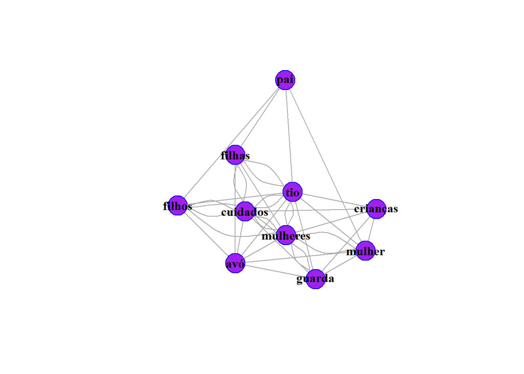

```r
load("cuid.RData")
library(igraph) #usando o pacote igraph para plotar a rede

g <- graph_from_data_frame(cuid, directed = FALSE)
l <- layout_with_fr(g)


plot(g, vertex.label = V(g)$name, edge.size=20, vertex.size=20,
     edge.arrow.size=05, vertex.label.dist=0,
      vertex.size2 = 30, vertex.label.font = 2, vertex.color = "purple",
     vertex.frame.color = "blue", vertex.label.color = "black",
     layout = l)
```

A rede de associações demonstra a partir da distância entre os vértices o grau de associação entre as palavras. Como se pode notar, em geral as figuras do gênero feminino (`avó`, `mulheres`, `mulher`) estão associadas ao cuidado, à guarda e a filhos e a crianças. Ao mesmo tempo, é notável como a figura masculina do pai está distante de todas essas palavras relacionadas ao cuidado. A exceção é a figura masculina do tio que parece mais associada ao cuidado.

Tal rede demonstra que as decisões jurídicas reflitem uma realidade social em que as figuras masculinas se ausentam do cuidado e da guarda. Mas ao mesmo tempo, é provável que estas próprias decisões reproduzam tal dinâmica, de modo que em caso de prisão da mãe a guarda é transferida para outras figuras femininas, reforçando a ideia social de que as mulheres são responsáveis pelo cuidado.